# Predicting distributional ranges of rocky intertidal species using a multi-dataset approach

Author

Simons D-L, Hipperson H, Webb TJ, Spencer M, Mieszkowska N

## Introduction

This pipeline replicates all analyses in Simons *et al* (2025) “Predicting distributional ranges of rocky intertidal species using a multi-dataset approach”.

Multiple resources have been used in this pipeline, including this [SDM guide](https://rspatial.org/sdm/index.html), Tom’s Euro benthos habitat species guide, and `biomod2` tutorials.

## Set-up

### Load packages

```r
packages <- c("devtools",
              "qiime2R", #github download
              "microbiome", #github download
              "tidyverse",
              "vegan",
              "ggforce",
              "phyloseq",
              "cowplot",
              "geosphere",
              'lme4',
              "car",
              "sf",
              "pROC", #ROC and AUC for model validation
              "ncdf4",
              "raster",
              "lubridate",
              "terra",
              "geodata",
              "predicts",
              "sdmpredictors",
              "tidyterra",
              "exactextractr",
              "arrow",
              "here",
              "emodnet.wfs", #github
              "biooracler",#github
              "biomod2",
              "dismo",
              "xgboost",
              "caret",
              "gam",
              "mda",
              "earth",
              "maxnet",
              "randomForest",
              "RODBC",
              "odbc")

# Install any missing packages along with their dependencies
new.packages <- packages[!(packages %in% installed.packages()[, "Package"])]
if (length(new.packages)) install.packages(new.packages, dependencies = TRUE)

# Load all packages
invisible(lapply(packages, library, character.only = TRUE))
```

### Functions

```r
get_nearest_coastline <- function(environment_stack, occurance_data, condition) {

  # convert to Spatraster
  env_terra <- rast(environment_stack)

  # Get CRS from raster
  raster_crs <- crs(env_terra, proj = TRUE)

  # Create original points as SpatVector
  points <- vect(occurance_data,
                 geom = c("lon", "lat"),
                 crs = raster_crs)

  # Extract environmental values at points
  presvals <- extract(env_terra, points)

  # Identify rows where all extracted values (except ID) are NA
  na_rows <- which(apply(presvals[, -1], 1, function(x) all(is.na(x))))

  # Create mask for coastline cells (where condition == 1)
  coastline_mask <- condition == 1

  # Extract points representing coastline cells
  coastline_points <- as.points(coastline_mask, values = FALSE)

  # Extract coordinates from original points
  coords <- crds(points)

  # For each NA point, find closest coastline point and replace coordinates
  for (i in na_rows) {
    this_point <- points[i]
    dists <- distance(this_point, coastline_points)
    nearest_idx <- which.min(dists)
    nearest_coords <- crds(coastline_points[nearest_idx])

    coords[i, ] <- nearest_coords
  }

  # Rebuild corrected SpatVector with updated coordinates
  corrected_points <- vect(data.frame(occurance_data, coords),
                           geom = c("x", "y"),
                           crs = crs(points))

  # Extract environmental variables at corrected points
  #presvals_corrected <- extract(env_terra, corrected_points)

  return(corrected_points)
}
```

```r
snap_to_nearest_valid <- function(environment_stack, occurance_data) {

  # Select lon/lat columns using dplyr
  coords <- occurance_data %>% select(c(lon, lat))

  # Convert to SpatialPoints for raster extraction
  pts <- SpatialPoints(coords, proj4string = crs(environment_stack))

  # Extract raster values at occurrence points
  vals <- raster::extract(environment_stack, pts)

  # Identify points on any NA across layers
  na_points <- apply(vals, 1, function(x) any(is.na(x)))

  # Identify valid cells (no NAs in any layer)
  valid_cells <- Which(
    !is.na(environment_stack[[1]]) & !is.na(environment_stack[[2]]) & !is.na(environment_stack[[3]]),
    cells = TRUE
  )
  valid_xy <- xyFromCell(environment_stack, valid_cells)

  # Initialize corrected coordinates
  corrected_coords <- coords

  # Snap only points on NA cells
  if(any(na_points)) {
    nn <- FNN::get.knnx(valid_xy, coords[na_points, , drop = FALSE], k = 1)
    corrected_coords[na_points, ] <- valid_xy[nn$nn.index, ]
  }

  return(corrected_coords)
}
```

```r
g_legend<-function(a.gplot){
  tmp <- ggplot_gtable(ggplot_build(a.gplot))
  leg <- which(sapply(tmp$grobs, function(x) x$name) == "guide-box")
  legend <- tmp$grobs[[leg]]
}
```

### Set seed

This is to make sure the random elements in models start from the same point every time. This will make our results reproducible. This is also done before any randomized element such as before each model.

```r
seed.val.set = 42 # life, the universe, and everything

options(biomod2.parallel = FALSE) # forces everything to run sequentially, so seeds behave more predictably
```

## Occurrence data

### Import paired eDNA and MarClim occurrences

Let’s first read in our occurrences and metadata.

```r
# occurance data
occurance_data <- read.csv(file = "Data/Occurrence_data/my_dataset/combined_methods_long_data.csv", row.names = 1)

# get lat long from meta data
metadata <- read.csv(file = "Data/Metadata/metadata.csv", na.strings = c(""))
metadata <- metadata %>%
  subset(select = c(localityID, exposure, decimalLongitude, decimalLatitude)) %>% unique() %>% na.omit()

# add lat long to occurance
occurance_data <- left_join(occurance_data, metadata)

# filter to only species of interest
species_list <- c(
  "Semibalanus balanoides",
  "Phorcus lineatus",
  "Chthamalus montagui",
  "Perforatus perforatus",
  "Patella depressa",
  "Bifurcaria bifurcata",
  "Asterias rubens"
)

occurance_data_reduced <- occurance_data %>% filter(taxa %in% species_list)
str(occurance_data_reduced)
```

```
'data.frame':   406 obs. of  15 variables:
 $ taxa              : chr  "Asterias rubens" "Asterias rubens" "Asterias rubens" "Asterias rubens" ...
 $ localityID        : chr  "CN01" "CN02" "CN03" "CN04" ...
 $ count             : num  0 0 0 0 0 ...
 $ region            : chr  "Southwest England" "Southwest England" "Southwest England" "Southwest England" ...
 $ genus             : chr  "Asterias" "Asterias" "Asterias" "Asterias" ...
 $ site              : chr  "Lizard Point" "Sennen Cove" "Looe" "St Ives" ...
 $ phylum            : chr  "Echinodermata" "Echinodermata" "Echinodermata" "Echinodermata" ...
 $ method            : chr  "Visual" "Visual" "Visual" "Visual" ...
 $ pa                : int  0 0 0 0 0 0 0 0 0 1 ...
 $ num_samples       : int  NA NA NA NA NA NA NA NA NA NA ...
 $ num_samples_found : int  NA NA NA NA NA NA NA NA NA NA ...
 $ prop_samples_found: num  NA NA NA NA NA NA NA NA NA NA ...
 $ exposure          : chr  "Sheltered" "Moderatley exposed" "Moderatley exposed" "Exposed" ...
 $ decimalLongitude  : num  -5.21 -5.71 -4.46 -5.48 -4.99 ...
 $ decimalLatitude   : num  50 50.1 50.3 50.2 50.5 ...
```

Split into species of interest for combined and individual methods.

```r
# Clean species names to use in object names (e.g., "Semibalanus balanoides" -> "semibalanus")
clean_name <- function(name) {
  tolower(gsub(" ", "_", name))
}

# Loop through each species and create the filtered data frames
for (species in species_list) {
  clean <- clean_name(species)

  assign(paste0(clean, "_obs_both_methods"),
         occurance_data_reduced %>%
           filter(taxa == species, pa == 1) %>%
           select(taxa, decimalLongitude, decimalLatitude) %>%
           rename(lat = decimalLatitude, lon = decimalLongitude, species = taxa))

  assign(paste0(clean, "_obs_eDNA"),
         occurance_data_reduced %>%
           filter(taxa == species, method == "eDNA", pa == 1) %>%
           select(taxa, decimalLongitude, decimalLatitude) %>%
           rename(lat = decimalLatitude, lon = decimalLongitude, species = taxa))

  assign(paste0(clean, "_obs_visual"),
         occurance_data_reduced %>%
           filter(taxa == species, method == "Visual", pa == 1) %>%
           select(taxa, decimalLongitude, decimalLatitude) %>%
           rename(lat = decimalLatitude, lon = decimalLongitude, species = taxa))
}

# Check the data to make sure it loaded correctly
head(semibalanus_balanoides_obs_eDNA)
```

```
                 species     lon     lat
1 Semibalanus balanoides -5.7100 50.0780
2 Semibalanus balanoides -4.4580 50.3410
3 Semibalanus balanoides -5.4751 50.2178
4 Semibalanus balanoides -4.9850 50.5450
5 Semibalanus balanoides -0.2609 54.2158
6 Semibalanus balanoides -0.4079 54.3014
```

```r
# Determine geographic extent of our data
# find general latitudinal and longitudinal boundaries

max_lat <- ceiling(max(occurance_data_reduced$decimalLatitude))
min_lat <- floor(min(occurance_data_reduced$decimalLatitude))
max_lon <- ceiling(max(occurance_data_reduced$decimalLongitude))
min_lon <- floor(min(occurance_data_reduced$decimalLongitude))

# Store boundaries in a single extent object
geographic_extent <- ext(x = c(min_lon, max_lon, min_lat, max_lat))
uk_extent <- ext(-11, 2, 49.5, 61)  # Westernmost to easternmost, southernmost to northernmost
uk_extent_match <- ext(-10.8,2,49.4,60.8)

# plot features
wrld <- world(path=".")
```

### Import wider MarClim occurrences

MarClim has a broader range of sites than just the sites matched to our eDNA samples. We can use this as an evaluation data set because it contains close to true absence and presence for the sampled sites. We are going to stick to 2022 - 2023 period to keep things simple.

```r
# read
marclim_broad <- read.csv(file = "Data/Occurrence_data/my_dataset/MarClim_SACFOR_22_23.csv")

# filter for just semibalanus and chthamalus
marclim_broad_sp <- marclim_broad %>%
  select(Semibalanus.balanoides,
         Chthamalus.montagui,
         Lat..WGS84.,
         Long..WGS84.)

#convert to PA
marclim_broad_sp_PA <- marclim_broad_sp %>%
  mutate(across(
    c(Semibalanus.balanoides, Chthamalus.montagui),
    ~ ifelse(. %in% c("NR", "NS", "?", ""), 0, 1)
  )) %>% na.omit()

# tidy labels
marclim_broad_sp_PA <- marclim_broad_sp_PA %>%
  rename(
    lat = Lat..WGS84.,
    lon = Long..WGS84.
  )

#only within uK extent
marclim_broad_sp_PA <- subset(marclim_broad_sp_PA,
  lon >= -10.8 & lon <= 2 &
  lat >= 49.72 & lat <= 60.8
)

# make individual species presence only datasets for maps
semibalanus_marclim_broad <- marclim_broad_sp_PA %>%
  select(-c(Chthamalus.montagui)) %>%
  filter(Semibalanus.balanoides == 1) %>%
  mutate(species = "Semibalanus balanoides") %>%
  select(-c(Semibalanus.balanoides))

chthamalus_marclim_broad <- marclim_broad_sp_PA %>%
  select(-c(Semibalanus.balanoides)) %>%
  filter(Chthamalus.montagui == 1) %>%
  mutate(species = "Chthamalus montagui") %>%
  select(-c(Chthamalus.montagui))
```

### Import GBIF occurrences

We can also other occurrences from GBIF. These have been # for now to save time and memory. They have been loaded directly in.

```r
minYear = 2022

# Semibalanus

#semibalanus_GBIF_obs <- geodata::sp_occurrence("semibalanus", "balanoides", geo=TRUE, ext = uk_extent)
#dups <- duplicated(semibalanus_GBIF_obs[, c('lon', 'lat')])
#semibalanus_GBIF_obs_nodups <- semibalanus_GBIF_obs[!dups, ]
#semibalanus_GBIF_obs_nodups_recent <- subset(semibalanus_GBIF_obs_nodups, year >= minYear)
#dim(semibalanus_GBIF_obs_nodups_recent)

#write.csv(semibalanus_GBIF_obs_nodups_recent, file = paste("Data/Occurrence_data/GBIF/semibalanus_",minYear,".csv", sep = ""))

semibalanus_GBIF_clean <- read.csv("Data/Occurrence_data/GBIF/semibalanus_2022.csv")

# we only want 2022 and 2023 to match survey data
semibalanus_GBIF_clean <- semibalanus_GBIF_clean %>%
  filter(year %in% c(2022, 2023),
         country %in% c("United Kingdom", "Isle of Man")) %>%  #filter out Ireland
  filter(!(lon > -8.2 & lon < -5.4 & lat > 54.0 & lat < 55.3)) # filter out Northern Ireland

# Phorcus

#phorcus_GBIF_obs <- geodata::sp_occurrence("phorcus", "lineatus", geo=TRUE, ext = uk_extent)
#dups <- duplicated(phorcus_GBIF_obs[, c('lon', 'lat')])
#phorcus_GBIF_obs_nodups <- phorcus_GBIF_obs[!dups, ]
##phorcus_GBIF_obs_nodups_recent <- subset(phorcus_GBIF_obs_nodups, year >= minYear)

#write.csv(phorcus_GBIF_obs_nodups_recent, file = paste("Data/Occurrence_data/GBIF/phorcus_",minYear,".csv", sep = ""))

phorcus_GBIF_clean <- read.csv("Data/Occurrence_data/GBIF/phorcus_2020.csv")

# Chthamalus

#chthamalus_GBIF_obs <- geodata::sp_occurrence("chthamalus", "montagui", geo=TRUE, ext = uk_extent)
#dups <- duplicated(chthamalus_GBIF_obs[, c('lon', 'lat')])
#chthamalus_GBIF_obs_nodups <- chthamalus_GBIF_obs[!dups, ]
#chthamalus_GBIF_obs_nodups_recent <- subset(chthamalus_GBIF_obs_nodups, year >= minYear)

#write.csv(chthamalus_GBIF_obs_nodups_recent, file = paste("Data/Occurrence_data/GBIF/chthamalus_",minYear,".csv", sep = ""))

chthamalus_GBIF_clean <- read.csv("Data/Occurrence_data/GBIF/chthamalus_2022.csv")

# we only want 2022 and 2023 to match survey data
chthamalus_GBIF_clean <- chthamalus_GBIF_clean %>%
  filter(year %in% c(2022, 2023),
         country %in% c("United Kingdom","Isle of Man")) %>%  #filter out Ireland
  filter(!(lon > -8.2 & lon < -5.4 & lat > 54.0 & lat < 55.3)) # filter out Northern Ireland

# Perforatus perforatus

#perforatus_GBIF_obs <- geodata::sp_occurrence("perforatus", "perforatus", geo=TRUE, ext = uk_extent)
#dups <- duplicated(perforatus_GBIF_obs[, c('lon', 'lat')])
#perforatus_GBIF_obs_nodups <- perforatus_GBIF_obs[!dups, ]
#perforatus_GBIF_obs_nodups_recent <- subset(perforatus_GBIF_obs_nodups, year >= minYear)

#write.csv(perforatus_GBIF_obs_nodups_recent, file = paste("Data/Occurrence_data/GBIF/perforatus_",minYear,".csv", sep = ""))

perforatus_GBIF_clean <- read.csv("Data/Occurrence_data/GBIF/perforatus_2020.csv")

# Patella depressa

#patella_GBIF_obs <- geodata::sp_occurrence("patella", "depressa", geo=TRUE, ext = uk_extent)
#dups <- duplicated(patella_GBIF_obs[, c('lon', 'lat')])
#patella_GBIF_obs_nodups <- patella_GBIF_obs[!dups, ]
#patella_GBIF_obs_nodups_recent <- subset(patella_GBIF_obs_nodups, year >= minYear)

##write.csv(patella_GBIF_obs_nodups_recent, file = paste("Data/Occurrence_data/GBIF/patella_",minYear,".csv", sep = ""))

patella_GBIF_clean <- read.csv("Data/Occurrence_data/GBIF/patella_2020.csv")

# Bifurcaria bifurcata

#bifurcaria_GBIF_obs <- geodata::sp_occurrence("Bifurcaria", "bifurcata", geo=TRUE, ext = uk_extent)
#dups <- duplicated(bifurcaria_GBIF_obs[, c('lon', 'lat')])
#bifurcaria_GBIF_obs_nodups <- bifurcaria_GBIF_obs[!dups, ]
#bifurcaria_GBIF_obs_nodups_recent <- subset(bifurcaria_GBIF_obs_nodups, year >= minYear)

#write.csv(bifurcaria_GBIF_obs_nodups_recent, file = paste("Data/Occurrence_data/GBIF/bifurcaria_",minYear,".csv", sep = ""))

bifurcaria_GBIF_clean <- read.csv("Data/Occurrence_data/GBIF/bifurcaria_2020.csv")
```

### Create data sets for model

We need 1) MarClim alone (as the evaluation data set), 2) GBIF alone as the visual data set, and 3) GBIF + eDNA.

```r
# combined GBIF and Marclim
semibalanus_GBIF_clean_reduced <- semibalanus_GBIF_clean %>%
  mutate(species = as.factor(species),
         source = "GBIF") %>%
  select(species, lat, lon, source)

semibalanus_marclim_broad$source <- "MarClim"
final_visual_semibalanus <- rbind(semibalanus_GBIF_clean_reduced, semibalanus_marclim_broad)

# combining visual + eDNA (all)
semibalanus_balanoides_obs_eDNA$source <- "eDNA"
final_combined_semibalanus <- rbind(final_visual_semibalanus, semibalanus_balanoides_obs_eDNA) # plused 26 observations

# GBIF + eDNA
semibalanus_GBIF_eDNA <- rbind(semibalanus_GBIF_clean_reduced, semibalanus_balanoides_obs_eDNA) # plused 26 observations

# marclim alone
semibalanus_marclim_broad <- semibalanus_marclim_broad %>%
  select(c(species, lat, lon))

# GBIF alone
semibalanus_GBIF_clean_reduced <- semibalanus_GBIF_clean_reduced %>%
  select(c(species, lat, lon))
```

We now have a few data sets for each species.

```r
head(semibalanus_marclim_broad) # marclim alone
```

```
                 species     lat     lon
1 Semibalanus balanoides 50.8362 -4.5592
2 Semibalanus balanoides 50.6330 -2.3760
3 Semibalanus balanoides 50.5130 -2.4600
4 Semibalanus balanoides 50.5414 -2.4544
5 Semibalanus balanoides 50.6070 -1.9450
6 Semibalanus balanoides 50.6062 -2.4448
```

```r
head(semibalanus_GBIF_clean_reduced) #GBIF alone
```

```
                 species      lat       lon
1 Semibalanus balanoides 53.50389 -3.065073
2 Semibalanus balanoides 53.50558 -3.063928
3 Semibalanus balanoides 51.21275 -3.473825
4 Semibalanus balanoides 51.21076 -3.455478
5 Semibalanus balanoides 54.08815 -4.760481
6 Semibalanus balanoides 53.41149 -4.512921
```

```r
head(semibalanus_GBIF_eDNA) #GBIF + eDNA
```

```
                 species      lat       lon source
1 Semibalanus balanoides 53.50389 -3.065073   GBIF
2 Semibalanus balanoides 53.50558 -3.063928   GBIF
3 Semibalanus balanoides 51.21275 -3.473825   GBIF
4 Semibalanus balanoides 51.21076 -3.455478   GBIF
5 Semibalanus balanoides 54.08815 -4.760481   GBIF
6 Semibalanus balanoides 53.41149 -4.512921   GBIF
```

```r
head(final_visual_semibalanus) #MarClim + GBIF
```

```
                 species      lat       lon source
1 Semibalanus balanoides 53.50389 -3.065073   GBIF
2 Semibalanus balanoides 53.50558 -3.063928   GBIF
3 Semibalanus balanoides 51.21275 -3.473825   GBIF
4 Semibalanus balanoides 51.21076 -3.455478   GBIF
5 Semibalanus balanoides 54.08815 -4.760481   GBIF
6 Semibalanus balanoides 53.41149 -4.512921   GBIF
```

```r
head(final_combined_semibalanus) #all visual + eDNA
```

```
                 species      lat       lon source
1 Semibalanus balanoides 53.50389 -3.065073   GBIF
2 Semibalanus balanoides 53.50558 -3.063928   GBIF
3 Semibalanus balanoides 51.21275 -3.473825   GBIF
4 Semibalanus balanoides 51.21076 -3.455478   GBIF
5 Semibalanus balanoides 54.08815 -4.760481   GBIF
6 Semibalanus balanoides 53.41149 -4.512921   GBIF
```

Same again for chthamalus.

```r
# combined GBIF and Marclim
chthamalus_GBIF_clean_reduced <- chthamalus_GBIF_clean %>%
  mutate(species = as.factor(species),
         source = "GBIF") %>%
  select(species, lat, lon, source)

chthamalus_marclim_broad$source <- "MarClim"
final_visual_chthamalus <- rbind(chthamalus_GBIF_clean_reduced, chthamalus_marclim_broad)

# combining visual + eDNA
chthamalus_montagui_obs_eDNA$source <- "eDNA"
final_combined_chthamalus <- rbind(final_visual_chthamalus, chthamalus_montagui_obs_eDNA)

# GBIF + eDNA
chthamalus_GBIF_eDNA <- rbind(chthamalus_GBIF_clean_reduced, chthamalus_montagui_obs_eDNA) # plused 26 observations

# marclim alone
chthamalus_marclim_broad <- chthamalus_marclim_broad %>%
  select(c(species, lat, lon))

# GBIF alone
chthamalus_GBIF_clean_reduced <- chthamalus_GBIF_clean_reduced %>%
  select(c(species, lat, lon))

# check
head(chthamalus_marclim_broad)
```

```
              species     lat     lon
1 Chthamalus montagui 50.8362 -4.5592
2 Chthamalus montagui 50.6330 -2.3760
3 Chthamalus montagui 50.5130 -2.4600
4 Chthamalus montagui 50.5414 -2.4544
5 Chthamalus montagui 50.6070 -1.9450
6 Chthamalus montagui 50.6080 -2.1320
```

```r
head(chthamalus_GBIF_clean_reduced)
```

```
              species      lat       lon
1 Chthamalus montagui 50.14580 -5.061596
2 Chthamalus montagui 50.54500 -4.982151
3 Chthamalus montagui 50.14791 -5.056024
4 Chthamalus montagui 50.14730 -5.057851
5 Chthamalus montagui 50.14545 -5.062843
6 Chthamalus montagui 51.18360 -3.309933
```

```r
head(chthamalus_GBIF_eDNA)
```

```
              species      lat       lon source
1 Chthamalus montagui 50.14580 -5.061596   GBIF
2 Chthamalus montagui 50.54500 -4.982151   GBIF
3 Chthamalus montagui 50.14791 -5.056024   GBIF
4 Chthamalus montagui 50.14730 -5.057851   GBIF
5 Chthamalus montagui 50.14545 -5.062843   GBIF
6 Chthamalus montagui 51.18360 -3.309933   GBIF
```

```r
head(final_visual_chthamalus)
```

```
              species      lat       lon source
1 Chthamalus montagui 50.14580 -5.061596   GBIF
2 Chthamalus montagui 50.54500 -4.982151   GBIF
3 Chthamalus montagui 50.14791 -5.056024   GBIF
4 Chthamalus montagui 50.14730 -5.057851   GBIF
5 Chthamalus montagui 50.14545 -5.062843   GBIF
6 Chthamalus montagui 51.18360 -3.309933   GBIF
```

```r
head(final_combined_chthamalus)
```

```
              species      lat       lon source
1 Chthamalus montagui 50.14580 -5.061596   GBIF
2 Chthamalus montagui 50.54500 -4.982151   GBIF
3 Chthamalus montagui 50.14791 -5.056024   GBIF
4 Chthamalus montagui 50.14730 -5.057851   GBIF
5 Chthamalus montagui 50.14545 -5.062843   GBIF
6 Chthamalus montagui 51.18360 -3.309933   GBIF
```

### Visualise occurrences

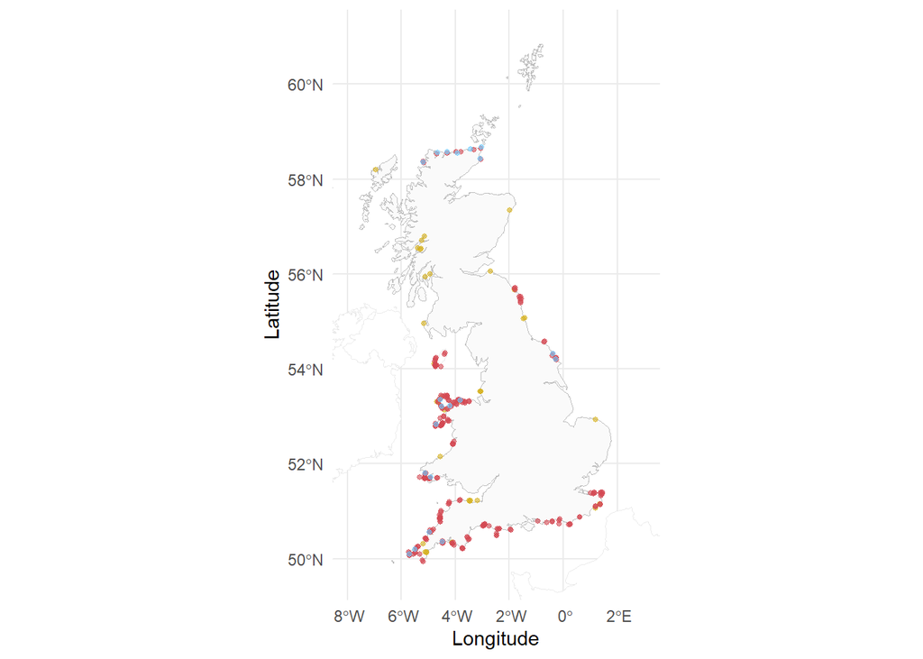

```r
# colours
GBIF_colour = "#D6B11F"
MarClim_colour = "#D44953"
eDNA_colour= "#70CBFF"

# Get UK boundaries at admin level 1 (countries/subunits)
uk <- rnaturalearth::ne_countries(country = c("United Kingdom"), returnclass = "sf", scale = "large")

northern_ireland <- rnaturalearth::ne_states(country = "United Kingdom", returnclass = "sf") %>%
  filter(geonunit == "Northern Ireland")   %>%
  st_union() %>%      # merge all the small pieces
  st_as_sf()          # back to sf object

other_maps <- rnaturalearth::ne_countries(country = c("Ireland", "Isle of Man", "France"), returnclass = "sf", scale = "large")

# Base ggplot map
semibalanus_map <- ggplot() +
  geom_sf(data = uk, fill = "grey98", color = "grey") +
  geom_sf(data = other_maps, fill = "white", color = "grey92") +
  geom_sf(data = northern_ireland, fill = "white", color = "grey92") +

  # Add all points with color mapped to 'source'
  geom_jitter(data = final_combined_semibalanus,
              aes(x = lon, y = lat, color = source),
              size = 1.1, width = 0.025, height = 0.025, alpha = 0.6) +

  coord_sf(xlim = c(-8, 3), ylim = c(49.7, 61)) +
  theme_minimal() +
  labs(x = "Longitude", y = "Latitude", color = "Data source") +
  scale_color_manual(values = c(
    "GBIF" = GBIF_colour,
    "MarClim" = MarClim_colour,
    "eDNA" = eDNA_colour
  )) +
  theme(legend.position = "none")

semibalanus_map
```

```r
# Save the plot
ggsave(semibalanus_map, filename = "Figures/semibalanus_map.png", width = 8, height = 6, dpi = 300)
```

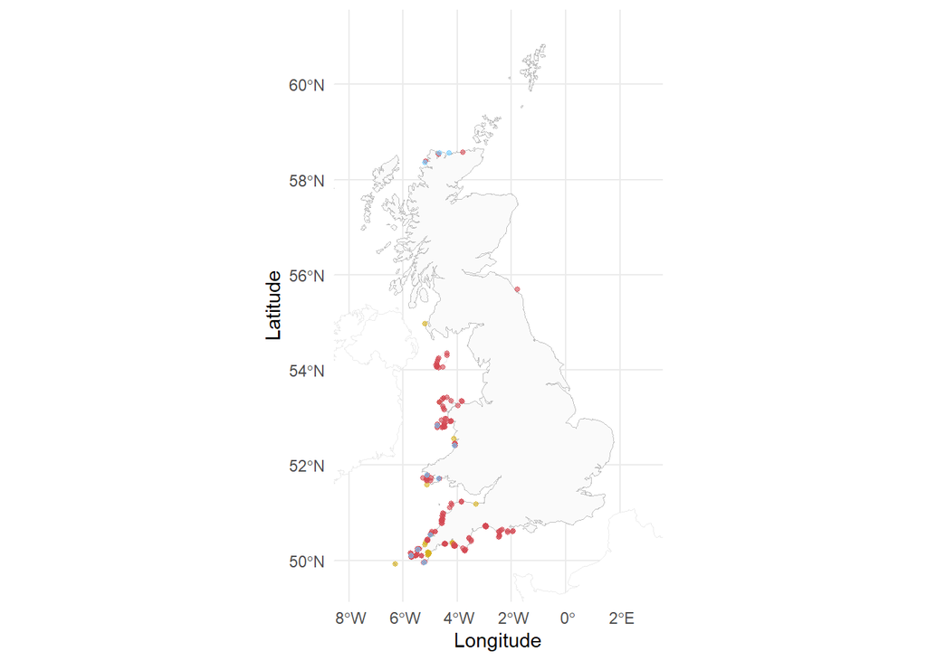

```r
# Base ggplot map
chthamalus_map_legend <- ggplot() +
  geom_sf(data = uk, fill = "grey98", color = "lightgray") +

  # need to jitter points a bit so that some are not hidden
  geom_jitter(data = final_combined_chthamalus,
              aes(x = lon, y = lat, color = source),
              size = 1.1, width = 0.025, height = 0.025, alpha = 0.6) +

  coord_sf(xlim = c(-9, 3), ylim = c(49.7, 61)) +
  theme_minimal() +
  labs(x = "Longitude", y = "Latitude", color = "Data source") +
  scale_color_manual(values = c(
    "GBIF" = GBIF_colour,
    "MarClim" = MarClim_colour,
    "eDNA" = eDNA_colour
  )) +
  theme(legend.position = "bottom")

chthamalus_map <- ggplot() +
  geom_sf(data = uk, fill = "grey98", color = "grey") +
  geom_sf(data = other_maps, fill = "white", color = "grey92") +
  geom_sf(data = northern_ireland, fill = "white", color = "grey92") +

  # need to jitter points a bit so that some are not hidden
  geom_jitter(data = final_combined_chthamalus,
              aes(x = lon, y = lat, color = source),
              size = 1.1, width = 0.025, height = 0.025, alpha = 0.6) +

  coord_sf(xlim = c(-8, 3), ylim = c(49.7, 61)) +
  theme_minimal() +
  labs(x = "Longitude", y = "Latitude", color = "Data source") +
  scale_color_manual(values = c(
    "GBIF" = GBIF_colour,
    "MarClim" = MarClim_colour,
    "eDNA" = eDNA_colour
  )) +
  theme(legend.position = "none")

chthamalus_map
```

```r
# Save the plot
ggsave(chthamalus_map, filename = "Figures/chthamalus_map.png", width = 8, height = 6, dpi = 300)
```

```r
legend <- g_legend(chthamalus_map_legend)
```

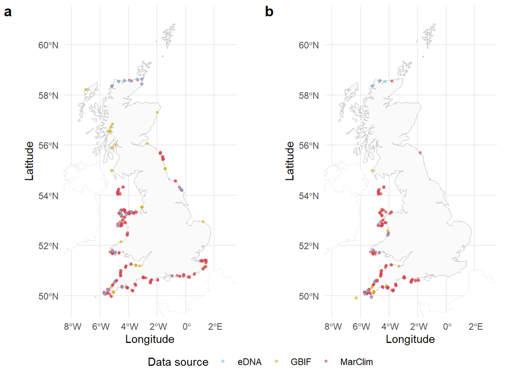

```r
joint_map <- cowplot::plot_grid(
  cowplot::plot_grid(semibalanus_map, chthamalus_map, ncol = 2, labels = c("a", "b"), rel_heights = c(0.8, 1)), legend, ncol =1, rel_heights = c(1, 0.06))


joint_map
```

```r
# Save the plot
ggsave(joint_map, filename = "Figures/chthamalus_semibalanus_map.png", width = 8, height = 6, dpi = 300)
```

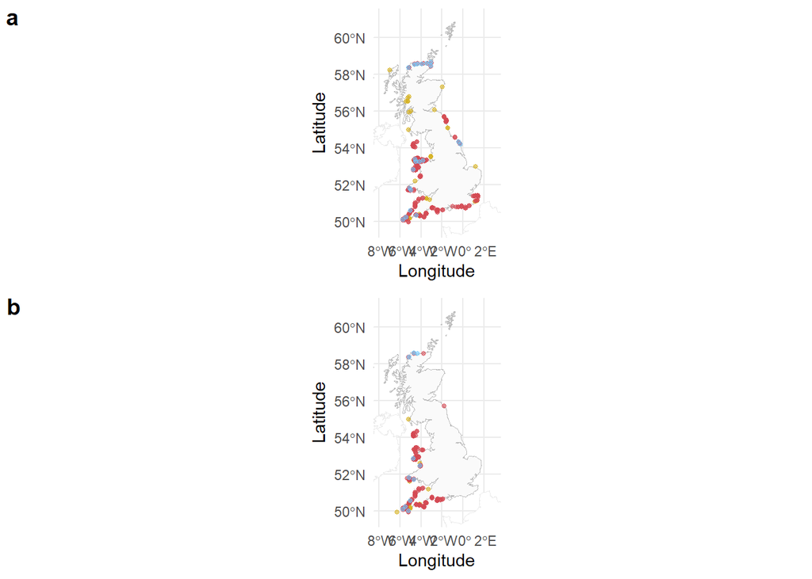

```r
joint_map_long <- cowplot::plot_grid(semibalanus_map, chthamalus_map, labels = c("a", "b"),rel_widths = c(1,1.5), ncol = 1, align = "v" )

joint_map_long
```

```r
# Save the plot
ggsave(joint_map_long, filename = "Figures/chthamalus_semibalanus_map_long.png", width = 6, height = 11, dpi = 300)
```

### Check for sampling bias

```r
# make a SpatVector
semibalanus_spat <- vect(final_visual_semibalanus, geom=c("lon", "lat"), crs="+proj=longlat +datum=WGS84")
class(semibalanus_spat)
```

```
[1] "SpatVector"
attr(,"package")
[1] "terra"
```

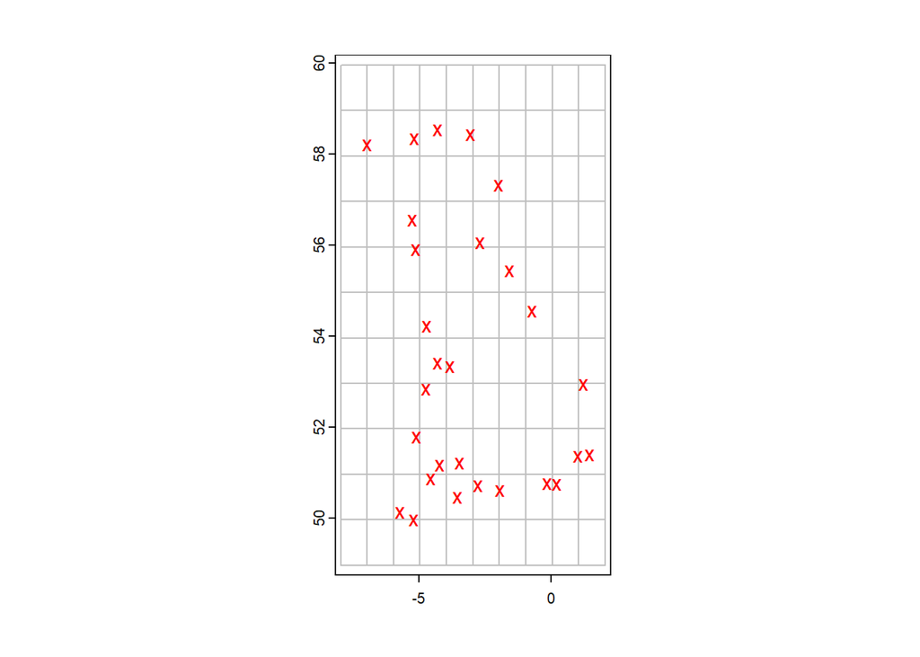

```r
# create a SpatRaster with the extent of acgeo
r <- rast(semibalanus_spat)

# set the resolution of the cells to (for example) 1 degree
res(r) <- 1

# extend (expand) the extent of the SpatRaster a little
r <- extend(r, ext(r)+1)

# sample:
set.seed(13)
acsel <- spatSample(semibalanus_spat, size=1, "random", strata=r)

# to illustrate the method and show the result
p <- as.polygons(r)
plot(p, border='gray')
points(semibalanus_GBIF_clean)
points(acsel, cex=1, col='red', pch='x') # selected points in red
```

### Absence and presence points (background points)

Let’s sample background points within a radius of presence points (as seen in VanDerWal et al, 2009).

*Blue points* are a subset of the grey points. These are points whose raster cell center falls within the buffer circles. They represent **final valid** **pseudo-absences**.

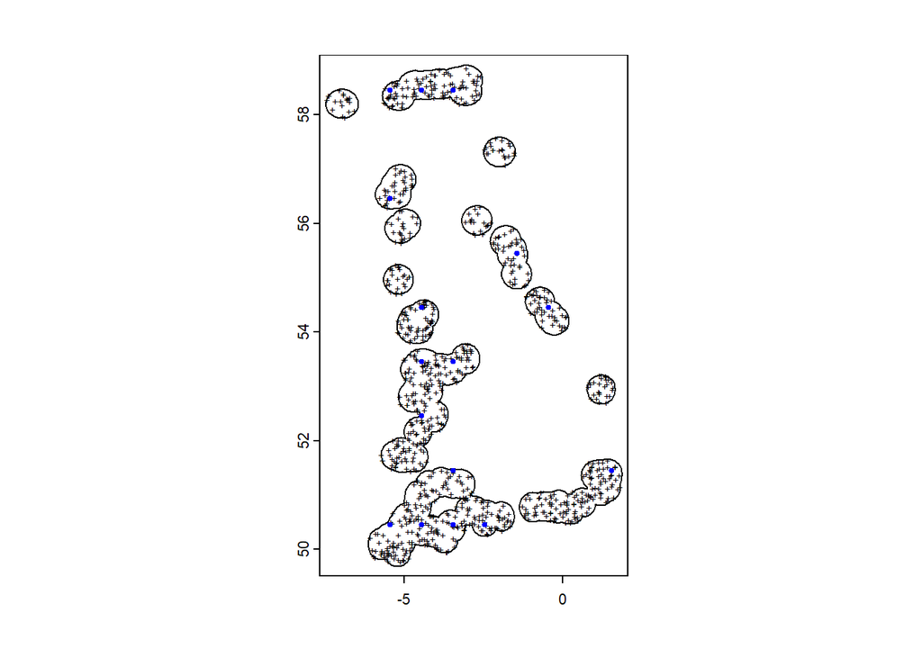

```r
# circles with a radius of 30 km
x <- raster::buffer(semibalanus_spat, 30000)
pol <- aggregate(x)

# take a random sample of points within the polygons.
# We only want one point per grid cell, sampling randomly from all circles
set.seed(999)
samp1 <- spatSample(pol, 1000, "random")

# no raster cells multiple times
pcells <- cells(r, samp1)
pcells <- unique(pcells[,2]) # remote duplicates
xy <- xyFromCell(r, pcells) # back to coordinates

# choose to select only those cells that have centers within circles
spxy <- vect(xy, crs="+proj=longlat +datum=WGS84")
xyInside <- intersect(spxy, x)

# plots to inspect results
plot(pol, axes=TRUE)
points(samp1, pch="+", cex=.5)
points(xyInside, cex=0.75, pch=20, col='blue')
```

## Environmental data

It’s time to find environmental variables of interest. We have a few options here - let’s explore them.

OCLE (https://ocle.ihcantabria.com/) provides meteo-oceanographic data for UK coastal communities, some of which are projected under future climate change scenarios. To match the resolution of the projected estimates, we are going to download annual mean for each variable. Summer mean is available for historic periods, but not for projected periods. Decided not to use this one.

```r
# set uk extent and colours
uk_extent <- extent(-8, 2, 49.7, 61)
cols <- colorRampPalette(c("blue", "lightblue", "yellow", "red"))(100)
```

### Temp, pH, coastline (Bio-ORCLE)

Bio-ORACLE is a comprehensive data set providing a wide range of marine environmental variables tailored for ecological and biogeographical analysis. These variables include surface and benthic values for parameters such as temperature, salinity, nutrients, oxygen, pH, and more, derived from satellite and modeled oceanographic data.

We use the `biooracler` package here to obtain our environmental variables of interest from current and projected periods.

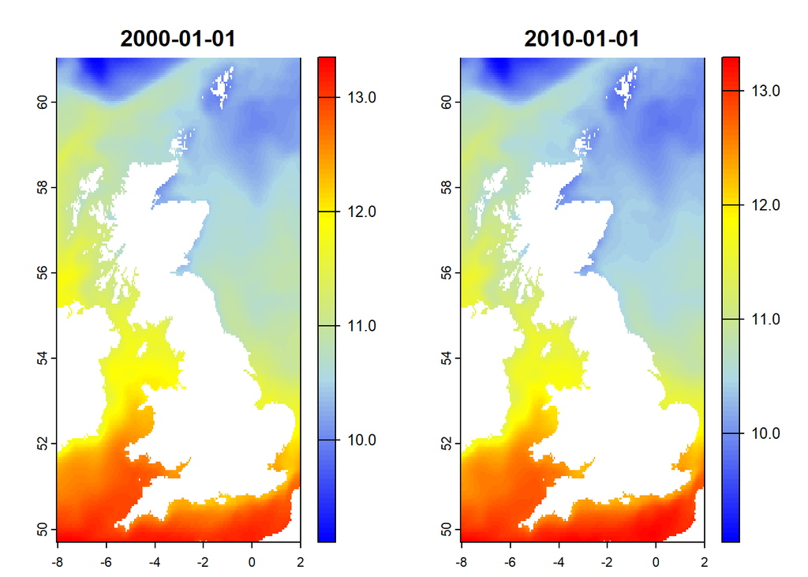

```r
## ocean temp
ocean_temp_present = readRDS("Data/Environmental_data/BIO-ORACLE/thetao_baseline_2000_2019_depthsurf.rds")
plot(
  ocean_temp_present,
  col = cols
)
```

```r
ocean_temp_avg <- mean(ocean_temp_present)
ocean_temp_avg
```

```
class       : SpatRaster
dimensions  : 227, 201, 1  (nrow, ncol, nlyr)
resolution  : 0.05, 0.05000001  (x, y)
extent      : -8.05, 2, 49.7, 61.05  (xmin, xmax, ymin, ymax)
coord. ref. : lon/lat WGS 84 (CRS84) (OGC:CRS84)
source(s)   : memory
name        :      mean
min value   :  9.076521
max value   : 13.317162
```

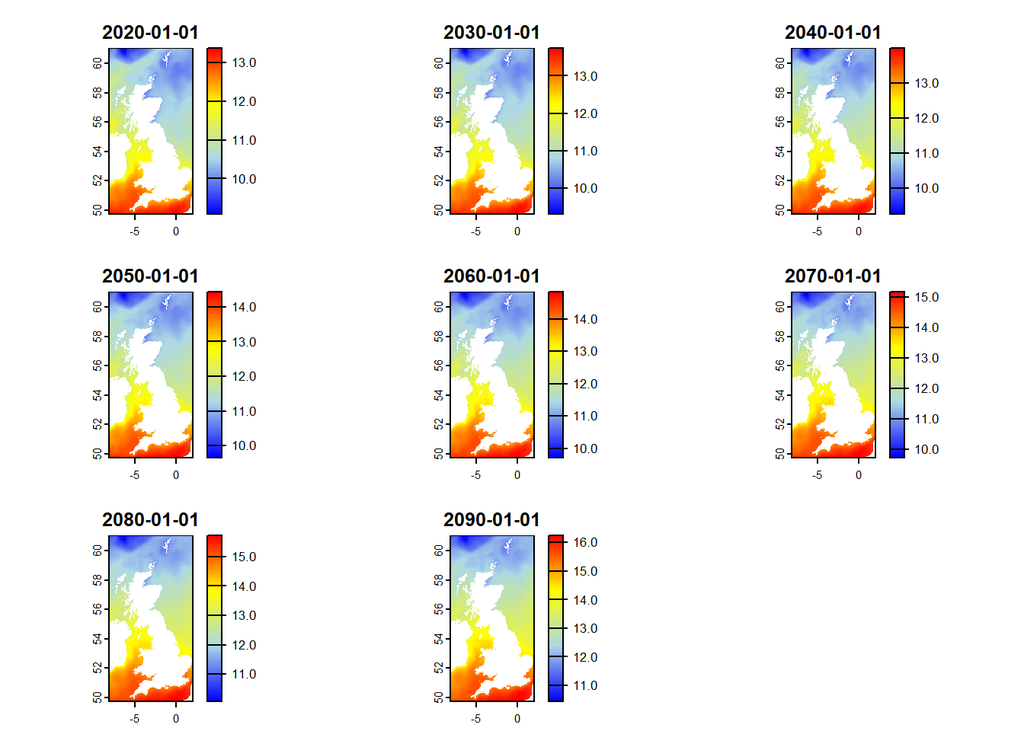

```r
ocean_temp_projected = readRDS("Data/Environmental_data/BIO-ORACLE/thetao_ssp585_2020_2100_depthsurf.rds")
plot(
  ocean_temp_projected,
  col = cols
)
```

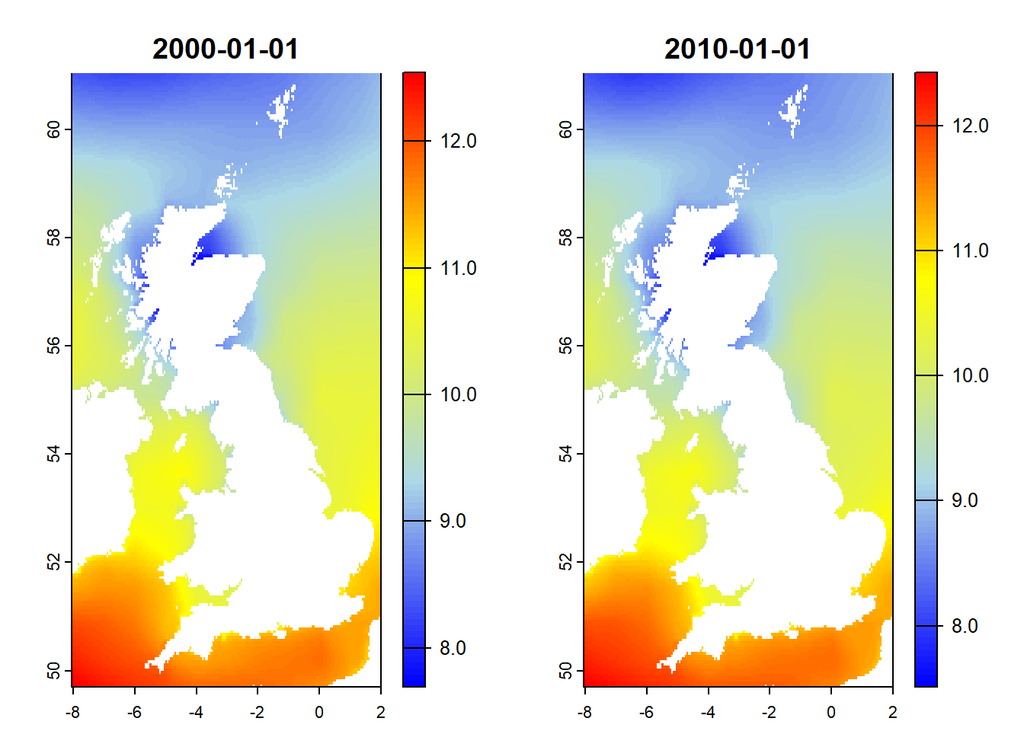

```r
ocean_temp_projected_90 = ocean_temp_projected["thetao_mean_8"]

## air temp
air_temp_present = readRDS("Data/Environmental_data/BIO-ORACLE/tas_baseline_2000_2020_depthsurf.rds")
plot(
  air_temp_present,
  col = cols
)
```

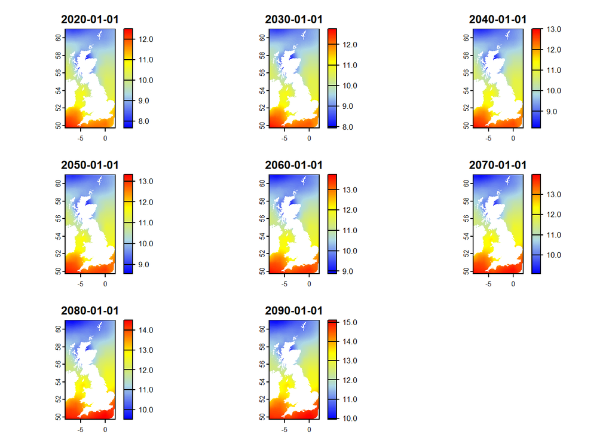

```r
air_temp_projected = readRDS("Data/Environmental_data/BIO-ORACLE/tas_ssp585_2020_2100_depthsurf.rds")
plot(
  air_temp_projected,
  col = cols
)
```

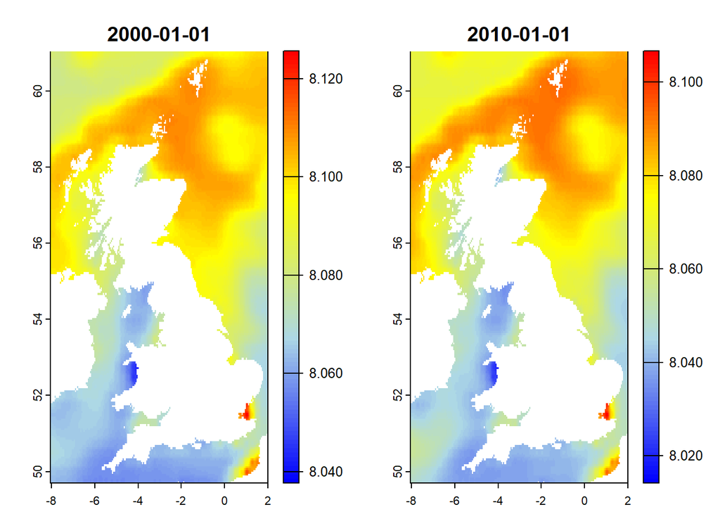

```r
## ph
ph_present = readRDS("Data/Environmental_data/BIO-ORACLE/ph_baseline_2000_2018_depthsurf.rds")
plot(ph_present,
     col = cols)
```

```r
ph_avg <- mean(ph_present)
ph_avg
```

```
class       : SpatRaster
dimensions  : 227, 201, 1  (nrow, ncol, nlyr)
resolution  : 0.05, 0.05000001  (x, y)
extent      : -8.05, 2, 49.7, 61.05  (xmin, xmax, ymin, ymax)
coord. ref. : lon/lat WGS 84 (CRS84) (OGC:CRS84)
source(s)   : memory
name        :     mean
min value   : 8.025923
max value   : 8.116090
```

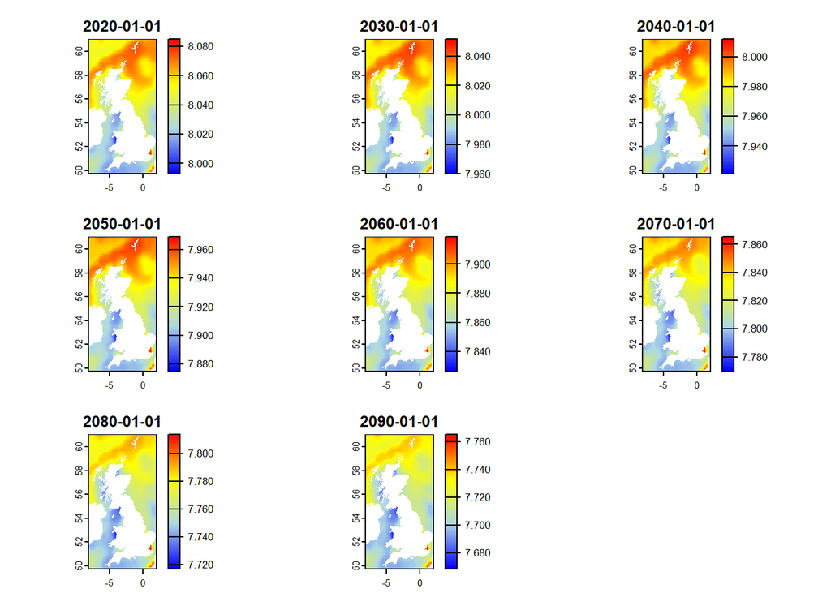

```r
ph_projected = readRDS("Data/Environmental_data/BIO-ORACLE/ph_ssp585_2020_2100_depthsurf.rds")
plot(ph_projected,
     col = cols)
```

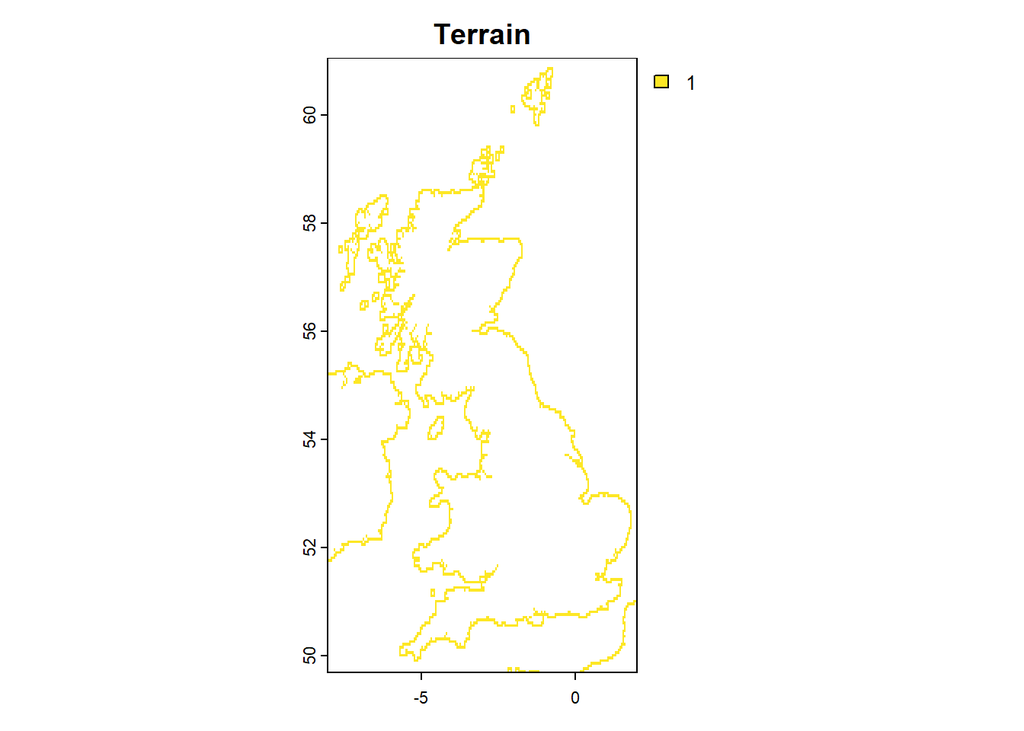

```r
ph_projected_90 <- ph_projected["ph_mean_8"]

# terrain
terrain <- readRDS("Data/Environmental_data/BIO-ORACLE/terrain_characteristics.rds")
plot(terrain,
     main = "Terrain")
```

### Rocky substrate (EMODnet & JNCC)

We can use the package `emodnet.wfs` to obtain a full UK habitat map from EMODnet servers. Documentation for this service is [here](https://docs.ropensci.org/emodnet.wfs/).

```r
# service information
#services <- emodnet_wfs()
#services[, c("emodnet_thematic_lot", "service_name")]

# initialising a client is the first step to interacting with an EMODnet Web Feature Services
#wfs_geo <- emodnet_init_wfs_client(service = "geology_seabed_substrate_maps")
#wfs_seabed <- emodnet_init_wfs_client(service =  "seabed_habitats_general_datasets_and_products")

# List contents of a WFS
#layer_info <- emodnet.wfs::emodnet_get_wfs_info(wfs_seabed)
#layer_info

# get descripion
#layer_info %>%
  #filter(layer_name == "ukseamap_latest_habitats") %>%
  #pull(abstract) %>%
  #cat()

# only UKASH Mosaic of Localised Maps includes intertidal zone

# define layer
#layers <- c("ukseamap_latest_habitats")

# get the data
#emodnet_substrate <- emodnet_get_layers(wfs = wfs_seabed,
                                        #layers = layers,
                                        #simplify = TRUE)
# explore the data
#emodnet_substrate
#unique(colnames(emodnet_substrate))
#unique(emodnet_substrate$eunis_name)
#unique(emodnet_substrate$country)

# get hard rock only - no littoral :(
#rock_hard_substrate <- emodnet_substrate %>%
  #filter(str_detect(str_to_lower(eunis_name), "rock"))

#plot (takes horrendously long)
#ggplot(rock_hard_substrate) +
  #geom_sf(aes(fill = eunis_name)) +
  #scale_fill_viridis_d(option = "plasma", name = "Substrate Type") +
  #coord_sf(crs = 4326) +
  #theme_minimal() +
  #labs(
    #title = "EMODnet Habitat Map",
    #x = "Longitude", y = "Latitude"
  #)
```

Unfortunately, we couldn’t get intertidal data from the above products. Let’s try the JNCC UKASH Mosaic of Localized Maps which does include intertidal data, but only for 12% of the UK.

```r
# Path to the unzipped .gdb folder for UKASH Mosaic of Localised Maps (with intertidal zone)
gdb_path <- "Data/Environmental_data/JNCC/UKASH_MosaicOfLocalisedMaps_v2025.gdb"

# List available layers
st_layers(gdb_path)
```

```
Driver: OpenFileGDB
Available layers:
                         layer_name geometry_type features fields crs_name
1 UKASH_MosaicLocalisedMaps_v2025_1 Multi Polygon   899864     20   WGS 84
```

```r
# read in
ukash <- st_read(gdb_path, layer = "UKASH_MosaicLocalisedMaps_v2025_1")
```

```
Simple feature collection with 899864 features and 20 fields
Geometry type: MULTIPOLYGON
Dimension:     XY
Bounding box:  xmin: -14.40942 ymin: 48.11506 xmax: 2.89474 ymax: 60.86268
Geodetic CRS:  WGS 84
```

```r
# explore
print(ukash)
```

```
Simple feature collection with 899864 features and 20 fields
Geometry type: MULTIPOLYGON
Dimension:     XY
Bounding box:  xmin: -14.40942 ymin: 48.11506 xmax: 2.89474 ymax: 60.86268
Geodetic CRS:  WGS 84
First 10 features:
   SNCB_UID EMODnetGUI  OrigCode
1             GB001446 M.AtLB.Ro
2             GB001446 M.AtLB.Ro
3             GB001446 M.AtLB.Ro
4             GB001446 M.AtLB.Ro
5             GB001446 M.AtLB.Ro
6             GB001446 M.AtLB.Ro
7             GB001446 M.AtLB.Ro
8             GB001446 M.AtLB.Ro
```

[output cut: 57 more lines]

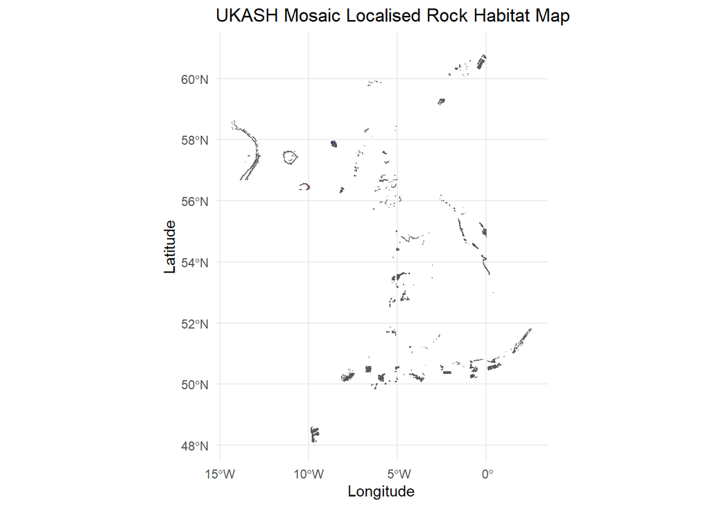

```r
# filter for rocky only
rock_ukash <- ukash %>%
  filter(str_detect(str_to_lower(OrigName), "rock"))

# make a raster and match format to the other environmental variables
rock_ukash_rast <- raster::rasterize(rock_ukash, ocean_temp_present)

# plot
rock_ukash_plot <- ggplot(rock_ukash) +
  geom_sf(aes(fill = OrigName)) +
  scale_fill_viridis_d(option = "plasma", name = "Substrate Type") +
  coord_sf(crs = 4326) +
  theme_minimal() +
  labs(
    title = "UKASH Mosaic Localised Rock Habitat Map",
    x = "Longitude", y = "Latitude"
  ) + theme(legend.position = "none")

rock_ukash_plot
```

```r
ggsave(rock_ukash_plot, filename = "Figures/UKASH_Mosaic_Localised_Rock.jpeg")
```

To get a better coverage, let’s import rocky habitat information from JNCC Marine Recorder Public UK snapshot.

Two Microsoft access databases (primary and secondary) are available at https://hub.jncc.gov.uk/assets/b9934e31-39b6-41f9-9364-d1e93db68307. The rocky habitat we are interested in are defined here - https://mhc.jncc.gov.uk/biotopes/jnccmncr00000003. Primary database contains locations, secondary contains biotypes.

```r
# lists the drivers already installed for excel, access ect...
unique(odbc::odbcListDrivers()[[1]])
```

```
[1] "SQL Server"
[2] "Microsoft Access Driver (*.mdb, *.accdb)"
[3] "Microsoft Excel Driver (*.xls, *.xlsx, *.xlsm, *.xlsb)"
[4] "Microsoft Access Text Driver (*.txt, *.csv)"
[5] "Microsoft Access dBASE Driver (*.dbf, *.ndx, *.mdx)"
```

```r
# set database locations
primary_dbname <- "Data/Environmental_data/JNCC/SnapshotDatav52_PUBLIC_20220124.mdb"
secondary_dbname <- "Data/Environmental_data/JNCC//SnapshotDatav52_PUBLIC_20220124_secondary.mdb"

# Establish connections between R and Access
RODBC::odbcCloseAll() # clear any existing
primary_con <- RODBC::odbcConnectAccess2007(primary_dbname)
secondary_con <- RODBC::odbcConnectAccess2007(secondary_dbname)

RODBC::sqlTables(primary_con)
```

```
                                                             TABLE_CAT
1  Data\\Environmental_data\\JNCC\\SnapshotDatav52_PUBLIC_20220124.mdb
2  Data\\Environmental_data\\JNCC\\SnapshotDatav52_PUBLIC_20220124.mdb
3  Data\\Environmental_data\\JNCC\\SnapshotDatav52_PUBLIC_20220124.mdb
4  Data\\Environmental_data\\JNCC\\SnapshotDatav52_PUBLIC_20220124.mdb
5  Data\\Environmental_data\\JNCC\\SnapshotDatav52_PUBLIC_20220124.mdb
6  Data\\Environmental_data\\JNCC\\SnapshotDatav52_PUBLIC_20220124.mdb
7  Data\\Environmental_data\\JNCC\\SnapshotDatav52_PUBLIC_20220124.mdb
8  Data\\Environmental_data\\JNCC\\SnapshotDatav52_PUBLIC_20220124.mdb
9  Data\\Environmental_data\\JNCC\\SnapshotDatav52_PUBLIC_20220124.mdb
10 Data\\Environmental_data\\JNCC\\SnapshotDatav52_PUBLIC_20220124.mdb
11 Data\\Environmental_data\\JNCC\\SnapshotDatav52_PUBLIC_20220124.mdb
12 Data\\Environmental_data\\JNCC\\SnapshotDatav52_PUBLIC_20220124.mdb
13 Data\\Environmental_data\\JNCC\\SnapshotDatav52_PUBLIC_20220124.mdb
14 Data\\Environmental_data\\JNCC\\SnapshotDatav52_PUBLIC_20220124.mdb
```

[output cut: 37 more lines]

```r
RODBC::sqlTables(secondary_con)
```

```
                                                                         TABLE_CAT
1  Data\\Environmental_data\\JNCC\\\\SnapshotDatav52_PUBLIC_20220124_secondary.mdb
2  Data\\Environmental_data\\JNCC\\\\SnapshotDatav52_PUBLIC_20220124_secondary.mdb
3  Data\\Environmental_data\\JNCC\\\\SnapshotDatav52_PUBLIC_20220124_secondary.mdb
4  Data\\Environmental_data\\JNCC\\\\SnapshotDatav52_PUBLIC_20220124_secondary.mdb
5  Data\\Environmental_data\\JNCC\\\\SnapshotDatav52_PUBLIC_20220124_secondary.mdb
6  Data\\Environmental_data\\JNCC\\\\SnapshotDatav52_PUBLIC_20220124_secondary.mdb
7  Data\\Environmental_data\\JNCC\\\\SnapshotDatav52_PUBLIC_20220124_secondary.mdb
8  Data\\Environmental_data\\JNCC\\\\SnapshotDatav52_PUBLIC_20220124_secondary.mdb
9  Data\\Environmental_data\\JNCC\\\\SnapshotDatav52_PUBLIC_20220124_secondary.mdb
10 Data\\Environmental_data\\JNCC\\\\SnapshotDatav52_PUBLIC_20220124_secondary.mdb
11 Data\\Environmental_data\\JNCC\\\\SnapshotDatav52_PUBLIC_20220124_secondary.mdb
12 Data\\Environmental_data\\JNCC\\\\SnapshotDatav52_PUBLIC_20220124_secondary.mdb
13 Data\\Environmental_data\\JNCC\\\\SnapshotDatav52_PUBLIC_20220124_secondary.mdb
14 Data\\Environmental_data\\JNCC\\\\SnapshotDatav52_PUBLIC_20220124_secondary.mdb
```

[output cut: 17 more lines]

```r
# Fetch the data from the SampleBiotopeAll table
locations <- RODBC::sqlFetch(primary_con, "Location", rownames = T)
SampleBiotopeAll <- RODBC::sqlFetch(secondary_con, "SampleBiotopeAll", rownames = T)

# Pull all the Biotope occurrence keys littoral habitats
Biotope_littoral <- SampleBiotopeAll %>%
  dplyr::filter(grepl("LR", BiotopeCode))  # matches any LR entries (includes eulittoral)

# join
biotype_location <- left_join(Biotope_littoral, locations, by = "ObjectId")
biotype_location_reduced <- biotype_location %>% select(ObjectId, BiotopeCode, Lat, Long, LatWGS84, LongWGS84, Qualifier, CoordinateSystem) %>% na.omit()

# remove uncertain
biotype_location_reduced_certain <- biotype_location_reduced %>%
  dplyr::filter(!grepl("Uncertain", Qualifier))

#visualise - looks like a some points are incorrect
rocky_map <- ggplot() +
  geom_sf(data = wrld, fill = "lightyellow", color = "lightgray") +

  # Add all points with color mapped to 'source'
  geom_jitter(data = biotype_location_reduced,
              aes(x = LongWGS84, y = LatWGS84, colour = Qualifier),
              size = 0.8, width = 0.025, height = 0.025) +
  coord_sf(xlim = c(-11, 3), ylim = c(49, 61)) +
  theme_minimal() +
  labs(x = "Longitude", y = "Latitude") #+
  theme(legend.position = "none")
```

```
List of 1
 $ legend.position: chr "none"
 - attr(*, "class")= chr [1:2] "theme" "gg"
 - attr(*, "complete")= logi FALSE
 - attr(*, "validate")= logi TRUE
```

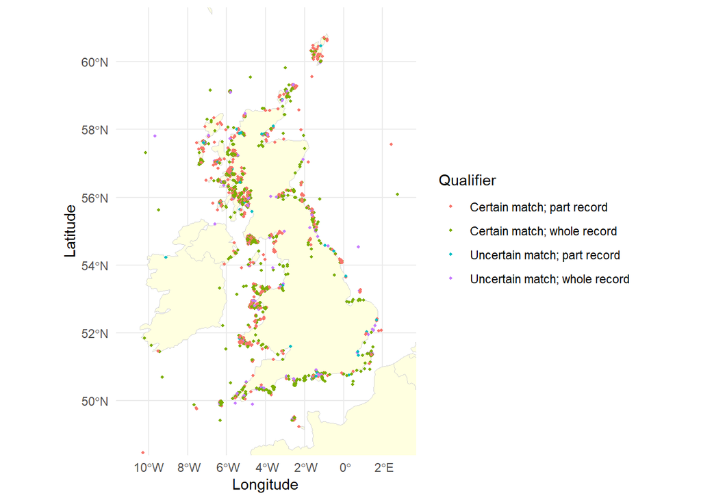

```r
rocky_map
```

```r
ggsave(rocky_map, filename = "Figures/JNCC_snapshot_littoral_map.jpeg")
```

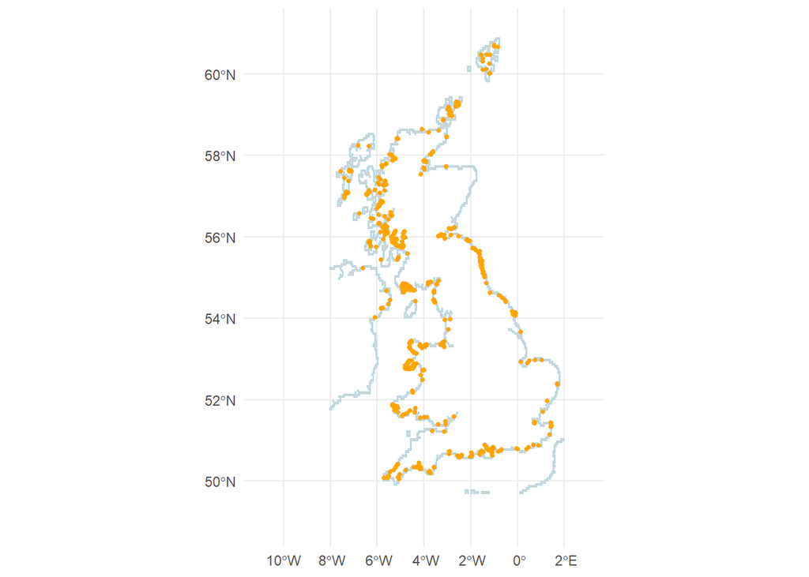

```r
# Convert raster coastline (value=1 for land) to polygons
coast_poly <- as.polygons(terrain, dissolve = TRUE, values = TRUE)

# Keep only the polygons where coastline == 1
coast_poly <- coast_poly[coast_poly$coastline == 1, ]

# Buffer (in degrees — ~0.01° ≈ 1.1 km at equator)
buffer_dist <- 0.03  # adjust based on desired intertidal width
coast_poly_buffered <- terra::buffer(coast_poly, width = buffer_dist)

# Make a SpatVector from Lat/Long WGS84
biotype_vect <- vect(
  biotype_location_reduced,
  geom = c("LongWGS84", "LatWGS84"),
  crs = "OGC:CRS84"
)

# Intersect points with buffered polygon
biotype_onshore_vect <- terra::intersect(biotype_vect, coast_poly_buffered)

# Convert points and polygon to sf
biotype_sf <- st_as_sf(biotype_onshore_vect)
coast_sf   <- st_as_sf(coast_poly_buffered)

# Plot
jncc_snapshot_littorial_tidy_map <- ggplot() +
  geom_sf(data = coast_sf, fill = "lightgray", color = "lightblue") +
  geom_sf(data = biotype_sf, size = 1, color = "orange") +
  coord_sf(xlim = c(-11, 3), ylim = c(49, 61)) + # adjust to your study area
  theme_minimal() +
  theme(legend.position = "none")

jncc_snapshot_littorial_tidy_map
```